# Zomato Exploration

## Preliminary Wrangling

> This dataset is provided by Zomato, and can be downloaded from [here](https://www.kaggle.com/shrutimehta/zomato-restaurants-data). It contains restaurants info, cuisines, prices and ratings

```python
# import all packages and set plots to be embedded inline
import numpy as np
import pandas as pd
import matplotlib.pyplot as plt
import seaborn as sb

%matplotlib inline
```

```python
restaurants_original = pd.read_csv("zomato.csv", encoding="ISO-8859-1")
restaurants_original.head()
```

|  | Restaurant ID | Restaurant Name | Country Code | City | Address | Locality | Locality Verbose | Longitude | Latitude | Cuisines | ... | Currency | Has Table booking | Has Online delivery | Is delivering now | Switch to order menu | Price range | Aggregate rating | Rating color | Rating text | Votes |
| --- | --- | --- | --- | --- | --- | --- | --- | --- | --- | --- | --- | --- | --- | --- | --- | --- | --- | --- | --- | --- | --- |
| 0 | 6317637 | Le Petit Souffle | 162 | Makati City | Third Floor, Century City Mall, Kalayaan Avenu... | Century City Mall, Poblacion, Makati City | Century City Mall, Poblacion, Makati City, Mak... | 121.027535 | 14.565443 | French, Japanese, Desserts | ... | Botswana Pula(P) | Yes | No | No | No | 3 | 4.8 | Dark Green | Excellent | 314 |
| 1 | 6304287 | Izakaya Kikufuji | 162 | Makati City | Little Tokyo, 2277 Chino Roces Avenue, Legaspi... | Little Tokyo, Legaspi Village, Makati City | Little Tokyo, Legaspi Village, Makati City, Ma... | 121.014101 | 14.553708 | Japanese | ... | Botswana Pula(P) | Yes | No | No | No | 3 | 4.5 | Dark Green | Excellent | 591 |
| 2 | 6300002 | Heat - Edsa Shangri-La | 162 | Mandaluyong City | Edsa Shangri-La, 1 Garden Way, Ortigas, Mandal... | Edsa Shangri-La, Ortigas, Mandaluyong City | Edsa Shangri-La, Ortigas, Mandaluyong City, Ma... | 121.056831 | 14.581404 | Seafood, Asian, Filipino, Indian | ... | Botswana Pula(P) | Yes | No | No | No | 4 | 4.4 | Green | Very Good | 270 |
| 3 | 6318506 | Ooma | 162 | Mandaluyong City | Third Floor, Mega Fashion Hall, SM Megamall, O... | SM Megamall, Ortigas, Mandaluyong City | SM Megamall, Ortigas, Mandaluyong City, Mandal... | 121.056475 | 14.585318 | Japanese, Sushi | ... | Botswana Pula(P) | No | No | No | No | 4 | 4.9 | Dark Green | Excellent | 365 |
| 4 | 6314302 | Sambo Kojin | 162 | Mandaluyong City | Third Floor, Mega Atrium, SM Megamall, Ortigas... | SM Megamall, Ortigas, Mandaluyong City | SM Megamall, Ortigas, Mandaluyong City, Mandal... | 121.057508 | 14.584450 | Japanese, Korean | ... | Botswana Pula(P) | Yes | No | No | No | 4 | 4.8 | Dark Green | Excellent | 229 |

5 rows × 21 columns

```python
restaurants_df = restaurants_original.copy()
```

```python
#Remove spaces from columns and replace them with underscores for easier manipulation with the data
restaurants_df.columns = restaurants_df.columns.str.replace(" ","_")
restaurants_df.columns = restaurants_df.columns.str.lower()
restaurants_df.info()
```

```
<class 'pandas.core.frame.DataFrame'>
RangeIndex: 9551 entries, 0 to 9550
Data columns (total 21 columns):
 #   Column                Non-Null Count  Dtype
---  ------                --------------  -----
 0   restaurant_id         9551 non-null   int64
 1   restaurant_name       9551 non-null   object
 2   country_code          9551 non-null   int64
 3   city                  9551 non-null   object
 4   address               9551 non-null   object
 5   locality              9551 non-null   object
 6   locality_verbose      9551 non-null   object
 7   longitude             9551 non-null   float64
 8   latitude              9551 non-null   float64
 9   cuisines              9542 non-null   object
 10  average_cost_for_two  9551 non-null   int64
 11  currency              9551 non-null   object
 12  has_table_booking     9551 non-null   object
 13  has_online_delivery   9551 non-null   object
 14  is_delivering_now     9551 non-null   object
 15  switch_to_order_menu  9551 non-null   object
 16  price_range           9551 non-null   int64
 17  aggregate_rating      9551 non-null   float64
 18  rating_color          9551 non-null   object
 19  rating_text           9551 non-null   object
 20  votes                 9551 non-null   int64
dtypes: float64(3), int64(5), object(13)
memory usage: 1.5+ MB
```

```python
# Convert restaurant_id to string for correct representation
restaurants_df.restaurant_id = restaurants_df.restaurant_id.astype("str")
```

```python
restaurants_df.rating_text.unique()
```

```
array(['Excellent', 'Very Good', 'Good', 'Average', 'Not rated', 'Poor'],
      dtype=object)
```

```python
# for now we consider not rated as a category, maybe dissmised later
ratings = ["Not rated", "Poor", "Average", "Good","Very Good","Excellent"]
ratings = pd.api.types.CategoricalDtype(ordered = True,
                                                categories = ratings)
restaurants_df["rating_text"] = restaurants_df["rating_text"].astype(ratings)
```

```python
restaurants_df.price_range.unique()
```

```
array([3, 4, 2, 1])
```

```python
price_range = [1,2,3,4]
price_range = pd.api.types.CategoricalDtype(ordered= True, categories = price_range)
restaurants_df.price_range = restaurants_df.price_range.astype(price_range)
```

```python
restaurants_df.switch_to_order_menu.unique()
```

```
array(['No'], dtype=object)
```

```python
#Drop unwanted columns
restaurants_df = restaurants_df.drop(["country_code","address","locality_verbose","longitude","latitude","aggregate_rating","rating_color", "switch_to_order_menu"], axis = 1)
```

```python
restaurants_df.rename(columns = {"rating_text":"rating"}, inplace= True)
restaurants_df.info()
```

```
<class 'pandas.core.frame.DataFrame'>
RangeIndex: 9551 entries, 0 to 9550
Data columns (total 13 columns):
 #   Column                Non-Null Count  Dtype
---  ------                --------------  -----
 0   restaurant_id         9551 non-null   object
 1   restaurant_name       9551 non-null   object
 2   city                  9551 non-null   object
 3   locality              9551 non-null   object
 4   cuisines              9542 non-null   object
 5   average_cost_for_two  9551 non-null   int64
 6   currency              9551 non-null   object
 7   has_table_booking     9551 non-null   object
 8   has_online_delivery   9551 non-null   object
 9   is_delivering_now     9551 non-null   object
 10  price_range           9551 non-null   category
 11  rating                9551 non-null   category
 12  votes                 9551 non-null   int64
dtypes: category(2), int64(2), object(9)
memory usage: 840.0+ KB
```

### What is the structure of your dataset?

> Now the dataset has 13 features, most of the variables are strings, `votes` & `average_cost_for_two` are numeric, and `price_range` & `rating` are ordered variables.

### What is/are the main feature(s) of interest in your dataset?

> I'm mainly interested two variables `cuisine` & `ratings` and how all other restaurant characterstics relate to them.

### What features in the dataset do you think will help support your investigation into your feature(s) of interest?

> All the features that were not dropped after the wrangling process are important and will help in my investigation, price ranges and average cost for two are very important ones to explore, also restaurants in some cities may tend to have certain ratings, the only feature that is not related to how the restaurant is rated is the number of votes, it shows how the ratings are credible though and may be a pointer to how the restaurant is popular

> For cuisines I'm interested to look at how different cities are related to certain cuisines, also the ratings for these cuisines are important maybe also per city, as some cuisines may be good in one place but not in other, and if there is a relation between cuisines and prices.

## Univariate Exploration

```python
restaurants_df.info()
```

```
<class 'pandas.core.frame.DataFrame'>
RangeIndex: 9551 entries, 0 to 9550
Data columns (total 13 columns):
 #   Column                Non-Null Count  Dtype
---  ------                --------------  -----
 0   restaurant_id         9551 non-null   object
 1   restaurant_name       9551 non-null   object
 2   city                  9551 non-null   object
 3   locality              9551 non-null   object
 4   cuisines              9542 non-null   object
 5   average_cost_for_two  9551 non-null   int64
 6   currency              9551 non-null   object
 7   has_table_booking     9551 non-null   object
 8   has_online_delivery   9551 non-null   object
 9   is_delivering_now     9551 non-null   object
 10  price_range           9551 non-null   category
 11  rating                9551 non-null   category
 12  votes                 9551 non-null   int64
dtypes: category(2), int64(2), object(9)
memory usage: 840.0+ KB
```

```python
restaurants_df.describe()
```

|  | average_cost_for_two | votes |
| --- | --- | --- |
| count | 9551.000000 | 9551.000000 |
| mean | 1199.210763 | 156.909748 |
| std | 16121.183073 | 430.169145 |
| min | 0.000000 | 0.000000 |
| 25% | 250.000000 | 5.000000 |
| 50% | 400.000000 | 31.000000 |
| 75% | 700.000000 | 131.000000 |
| max | 800000.000000 | 10934.000000 |

> Our two numeric variables appear to have high skewness

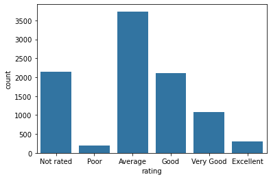

```python
base_color = sb.color_palette()[0]
sb.countplot(data = restaurants_df, x = "rating", color = base_color)
```

> We can see that poor and excellent are the lowest values, with average the highest, also we can separate `Not rated` and maintain our analysis between `Poor` and `Excellent` gradings and maybe let `Not rated` restaurants for another analysis.

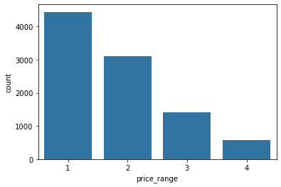

```python
base_color = sb.color_palette()[0]
sb.countplot(data = restaurants_df, x = "price_range", color = base_color);
```

> Most restaurant prices fall under lowest price category

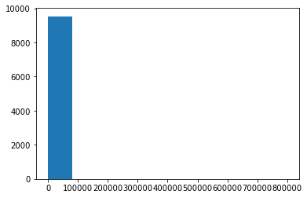

```python
plt.hist(data=restaurants_df, x = "average_cost_for_two");
```

> Average cost for two is very right skewed, suggesting the presence of outliers, this will need further investigation

```
(0.0, 10000.0)
```

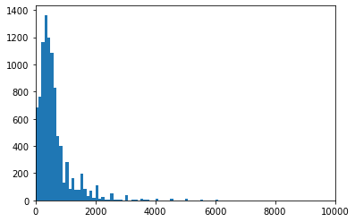

```python
# Limit our ticks between between 0 & 10000
bins = np.arange(0, 10000, 100)
plt.hist(data=restaurants_df, x = "average_cost_for_two", bins = bins)
plt.xlim(0,10000)
```

> still data is right skewed with most of the values between 0 and 2000

```
(0.0, 2000.0)
```

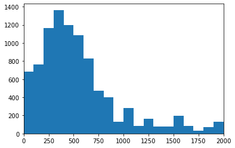

```python
# Limit our ticks between 0 & 2000
bins = np.arange(0, 2000 + 100, 100)
plt.hist(data=restaurants_df, x = "average_cost_for_two", bins = bins)
plt.xlim(0,2000)
```

> Most of the data is ditributed between 250 and about 600 with one peak around 400

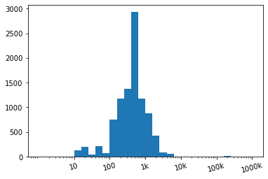

```python
bins  = 10** np.arange(0,np.log10(restaurants_df.average_cost_for_two.max())+ .2 ,.2)
plt.hist(data=restaurants_df, x = "average_cost_for_two", bins = bins);
plt.xscale("log")
plt.xticks([10, 100, 1e3, 1e4,1e5,1e6], ['10', '100', '1k', '10k', '100k', '1000k'], rotation = 15);
```

> Under log scale data is normally distributed with one peak around 400-500, there is a shift to the right as mentioned previously suggesting outliers that need more investigation

```python
restaurants_df.average_cost_for_two.describe()
```

```
count      9551.000000
mean       1199.210763
std       16121.183073
min           0.000000
25%         250.000000
50%         400.000000
75%         700.000000
max      800000.000000
Name: average_cost_for_two, dtype: float64
```

```python
restaurants_df.loc[restaurants_df.average_cost_for_two > 10000,:].head()
```

|  | restaurant_id | restaurant_name | city | locality | cuisines | average_cost_for_two | currency | has_table_booking | has_online_delivery | is_delivering_now | price_range | rating | votes |
| --- | --- | --- | --- | --- | --- | --- | --- | --- | --- | --- | --- | --- | --- |
| 9276 | 18400530 | Noah's Barn Coffeenery | Bandung | Dago | Cafe, Coffee and Tea, Western | 150000 | Indonesian Rupiah(IDR) | No | No | No | 3 | Very Good | 22 |
| 9277 | 7423620 | Momo Milk | Bogor | Bogor Timur | Cafe, Desserts, Beverages | 70000 | Indonesian Rupiah(IDR) | No | No | No | 2 | Good | 783 |
| 9278 | 7423482 | Lemongrass | Bogor | Bogor Utara | Peranakan, Indonesian | 250000 | Indonesian Rupiah(IDR) | No | No | No | 3 | Very Good | 1159 |
| 9279 | 7422633 | Talaga Sampireun | Jakarta | Cengkareng | Sunda, Indonesian | 200000 | Indonesian Rupiah(IDR) | No | No | No | 3 | Excellent | 1662 |
| 9280 | 7405789 | Toodz House | Jakarta | Fatmawati | Cafe, Italian, Coffee and Tea, Western, Indone... | 165000 | Indonesian Rupiah(IDR) | No | No | No | 3 | Excellent | 1476 |

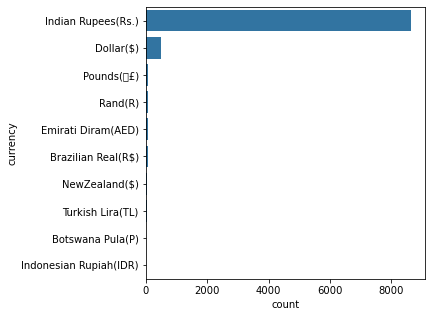

```python
currency_order = restaurants_df.currency.value_counts().index[:10]
plt.figure(figsize = (5,5))
sb.countplot(data = restaurants_df, y = "currency", order = currency_order, color = base_color);
```

> The distribution of `average_cost_for_two` was very highly skewed due to the different currencies in our dataset, this multiple currencies maybe due to multiple countries in our dataset. If they represent the same country though , we have to convert all our currencies to one currency like Rupees or US dollars for example, or explore our `average_cost_for_two` for different currencies in the bivariat exploration.

> From the above graph of currencies we see that most of our data are in Indian Rupees, this also suggests we can drop all other currencies and only focus on Rupees

```python
#Exploring cities first
restaurants_df[restaurants_df.currency != "Indian Rupees(Rs.)"].city.value_counts()[:10]
```

```
Manchester        20
Brasí_lia         20
Dubuque           20
Sioux City        20
Singapore         20
Gainesville       20
Orlando           20
Rest of Hawaii    20
Abu Dhabi         20
Doha              20
Name: city, dtype: int64
```

```python
restaurants_df[restaurants_df.currency == "Indian Rupees(Rs.)"].city.value_counts()[:5]
```

```
New Delhi    5473
Gurgaon      1118
Noida        1080
Faridabad     251
Ghaziabad      25
Name: city, dtype: int64
```

> After looking at the `city` & `currency` variables it's apparent why `average_cost_for_two` was very right skewed, this is due to different countries in our dataset having different currencies, for this analysis we will explore the indian market as it has the most data (Indian rupees)

```python
restaurants_df = restaurants_df[restaurants_df.currency == "Indian Rupees(Rs.)"] # drop all other currencies
```

## Reiterating our analysis

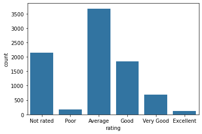

```python
base_color = sb.color_palette()[0]
sb.countplot(data = restaurants_df, x = "rating", color = base_color)
```

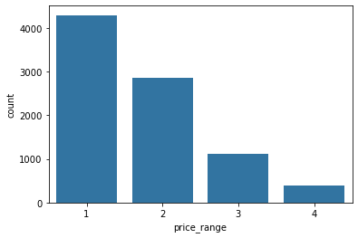

```python
base_color = sb.color_palette()[0]
sb.countplot(data = restaurants_df, x = "price_range", color = base_color);
```

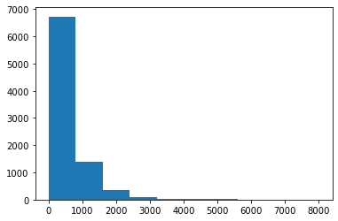

```python
plt.hist(data=restaurants_df, x = "average_cost_for_two");
```

> same skew but much less now as we factored out other currencies with very high values

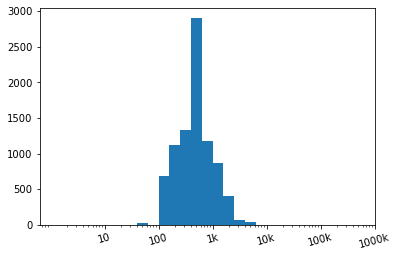

```python
bins  = 10** np.arange(0,np.log10(restaurants_df.average_cost_for_two.max())+ .2 ,.2)
plt.hist(data=restaurants_df, x = "average_cost_for_two", bins = bins);
plt.xscale("log")
plt.xticks([10, 100, 1e3, 1e4,1e5,1e6], ['10', '100', '1k', '10k', '100k', '1000k'], rotation = 15);
```

> Under log scale data is normally distributed with one peak around 500, most of the data is between 100 & 1K rupees

```python
restaurants_df.average_cost_for_two.describe()
```

```
count    8652.000000
mean      623.370319
std       595.676124
min         0.000000
25%       300.000000
50%       450.000000
75%       700.000000
max      8000.000000
Name: average_cost_for_two, dtype: float64
```

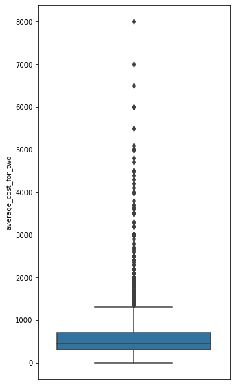

```python
plt.figure(figsize = (5,10))
sb.boxplot(data = restaurants_df, y = 'average_cost_for_two', color = base_color)
```

```python
print(restaurants_df.loc[restaurants_df.average_cost_for_two > 1500  ,:].sort_values("average_cost_for_two").shape)
restaurants_df.loc[restaurants_df.average_cost_for_two > 1500  ,:].sort_values("average_cost_for_two",ascending = False).head()
```

```
(540, 13)
```

|  | restaurant_id | restaurant_name | city | locality | cuisines | average_cost_for_two | currency | has_table_booking | has_online_delivery | is_delivering_now | price_range | rating | votes |
| --- | --- | --- | --- | --- | --- | --- | --- | --- | --- | --- | --- | --- | --- |
| 7543 | 2701 | Orient Express - Taj Palace Hotel | New Delhi | The Taj Palace Hotel, Chanakyapuri | European | 8000 | Indian Rupees(Rs.) | Yes | No | No | 4 | Very Good | 145 |
| 4088 | 309548 | Tian - Asian Cuisine Studio - ITC Maurya | New Delhi | ITC Maurya, Chanakyapuri | Asian, Japanese, Korean, Thai, Chinese | 7000 | Indian Rupees(Rs.) | No | No | No | 4 | Very Good | 188 |
| 4087 | 2742 | Bukhara - ITC Maurya | New Delhi | ITC Maurya, Chanakyapuri | North Indian | 6500 | Indian Rupees(Rs.) | No | No | No | 4 | Very Good | 2826 |
| 7538 | 2694 | Wasabi by Morimoto - The Taj Mahal Hotel | New Delhi | The Taj Mahal Hotel, Mansingh Road | Japanese, Sushi | 6000 | Indian Rupees(Rs.) | Yes | No | No | 4 | Good | 183 |
| 7494 | 2724 | 1911 - The Imperial | New Delhi | The Imperial, Janpath | North Indian, Chinese, South Indian, Italian | 6000 | Indian Rupees(Rs.) | Yes | No | No | 4 | Good | 272 |

> There are 540 restaurants that are supposed to be outliers in terms of their average cost for two, after looking at the data it seems fine as many restaurants tend to be in the overpriced category compared to the normal average prices, so they will not be dropped

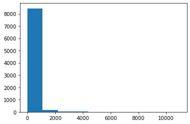

```python
plt.hist(data = restaurants_df, x = "votes");
```

> Same thing with votes data is highly skewed to the right

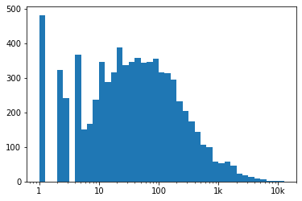

```python
bins  = 10** np.arange(0,np.log10(restaurants_df.votes.max())+ .1 ,.1)
plt.hist(data = restaurants_df, x = "votes",bins = bins )
plt.xscale("log")
plt.xticks([1, 10, 100, 1e3,1e4], ['1', '10', '100', '1k', '10k']);
```

> Under log scale votes have many peaks, many restaurants have only one vote this may need to be cleaned as they may lead to wrong ratings insights also many restaurants have peaks around 5 - 7 votes, 10 votes then the data takes a shape of a somehow multi-modal distribution with significant modes one between 10 and 50 the other is at 100.

> This also adds to interesting question, we need to have a threshold for restaurants with low number of votes to cast out of the analysis, but how much is low? i think it's a more business decision for the company while doing the analysis, for this analysis we'll keep all votes, but it's worth noting

```python
# separating cuisines to another dataframe as we will explode each row to multiple ones having only one cuisine
# for each row so one restaurant row will be copied to multiple rows to cover multiple cuisines.
cuisines_df = restaurants_df.copy()
cuisines = cuisines_df.cuisines.str.split(",").apply(pd.Series).stack()
#Leaving only original row index for each cuisine, so that it can be re-added
cuisines.index = cuisines.index.droplevel(-1)
cuisines.name = "cuisine"
```

```python
cuisines_df = cuisines_df.join(cuisines)
cuisines_df.shape
```

```
(17854, 14)
```

```python
cuisines_df.info()
```

```
<class 'pandas.core.frame.DataFrame'>
Int64Index: 17854 entries, 624 to 9275
Data columns (total 14 columns):
 #   Column                Non-Null Count  Dtype
---  ------                --------------  -----
 0   restaurant_id         17854 non-null  object
 1   restaurant_name       17854 non-null  object
 2   city                  17854 non-null  object
 3   locality              17854 non-null  object
 4   cuisines              17854 non-null  object
 5   average_cost_for_two  17854 non-null  int64
 6   currency              17854 non-null  object
 7   has_table_booking     17854 non-null  object
 8   has_online_delivery   17854 non-null  object
 9   is_delivering_now     17854 non-null  object
 10  price_range           17854 non-null  category
 11  rating                17854 non-null  category
 12  votes                 17854 non-null  int64
 13  cuisine               17854 non-null  object
dtypes: category(2), int64(2), object(10)
memory usage: 1.8+ MB
```

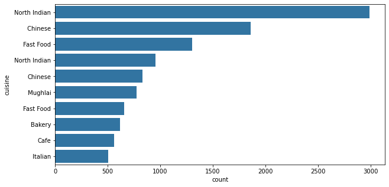

```python
cuisine_order = cuisines_df.cuisine.value_counts().index[:10]
plt.figure(figsize = (10,5))
sb.countplot(data = cuisines_df, y = "cuisine", order = cuisine_order, color = base_color);
```

> Some cuisines are repeated with same names, which suggests there are some unwanted spaces

```python
cuisines_df.cuisine = cuisines_df.cuisine.str.strip()
cuisines_df.cuisine.unique()
```

```
array(['North Indian', 'Mughlai', 'Rajasthani', 'Chinese', 'European',
       'Gujarati', 'Continental', 'South Indian', 'Desserts', 'Cafe',
       'Italian', 'Mexican', 'Pizza', 'Fast Food', 'Mediterranean',
       'Thai', 'Ice Cream', 'Beverages', 'Asian', 'Street Food',
       'Sandwich', 'Burger', 'Healthy Food', 'American', 'Armenian',
       'Salad', 'Bakery', 'Mithai', 'Biryani', 'Juices', 'Maharashtrian',
       'Hyderabadi', 'Modern Indian', 'Finger Food', 'Tex-Mex', 'Arabian',
       'Charcoal Grill', 'Steak', 'Seafood', 'Tea', 'Japanese',
       'Malaysian', 'Burmese', 'Chettinad', 'Spanish', 'Greek', 'Indian',
       'Parsi', 'Tibetan', 'Raw Meats', 'French', 'Goan', 'German',
       'Kerala', 'Lebanese', 'Belgian', 'Kashmiri', 'Sushi',
       'South American', 'Persian', 'Bengali', 'Portuguese', 'African',
       'Iranian', 'Vietnamese', 'Lucknowi', 'Korean', 'Awadhi',
       'Nepalese', 'Drinks Only', 'Pakistani', 'North Eastern', 'Oriya',
       'Bihari', 'Afghani', 'Middle Eastern', 'Indonesian', 'Assamese',
       'Andhra', 'Mangalorean', 'British', 'Malwani', 'Cuisine Varies',
       'Turkish', 'Moroccan', 'Naga', 'Deli', 'Sri Lankan', 'BBQ',
       'Cajun'], dtype=object)
```

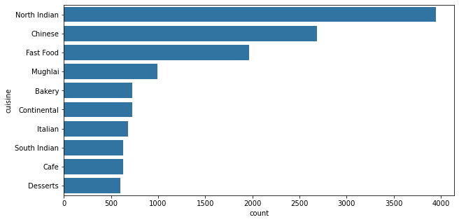

```python
cuisine_order = cuisines_df.cuisine.value_counts().index[:10]
plt.figure(figsize = (10,5))
sb.countplot(data = cuisines_df, y = "cuisine", order = cuisine_order, color = base_color);
```

> Interestingly North Indian food is more common than South Indian food, as North Indian is the No. 1 cuisine in terms of number of restaurants and South Indian comes in the 8th place

> Chinese, Fast Food are in the top 5 cuisines, also another famous unique cuisine which is called Mughlai, apparently it's an indian, turkish/persian influenced cuisine

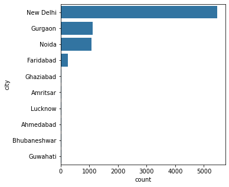

```python
city_order = restaurants_df.city.value_counts().index[:10]
plt.figure(figsize = (5,5))
sb.countplot(data = restaurants_df, y = "city", order = city_order, color = base_color);
```

> Restaurants in this dataset are mainly located in four areas, here's from top to bottom, New Delhi, Gurgaon, Noida, Faridabad, other areas can be dropped or grouped together

```python
yes_no_order = ["Yes", "No"]
```

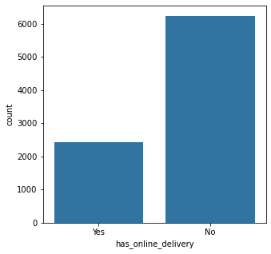

```python
plt.figure(figsize = (5,5))
sb.countplot(data = restaurants_df, x = "has_online_delivery", order= yes_no_order, color = base_color);
```

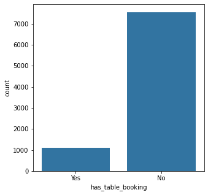

```python
plt.figure(figsize = (5,5))
sb.countplot(data = restaurants_df, x = "has_table_booking", order = yes_no_order ,color = base_color);
```

> This will be interesting to see in comparison to ratings, does restaurants with no online ordering or no table booking tend to have less ratings?

### Discuss the distribution(s) of your variable(s) of interest. Were there any unusual points? Did you need to perform any transformations?

> For the ratings variable, there were no unusual points or transformations, we can take several directions though with the Not rated portion of the data, either treat them as nans and drop them, or add them to our analysis and explore them further and see any interesting patterns or trends for the restaurants that are not rated.

> For the cuisines variable, I had to make a copy of the same data but tailored to cuisines, this is due to the fact that the cuisines column contained multiple cuisines for the same restaurant stored in the same cell, this would be a hassle to explore, I had to explode these rows into multiple rows with one cuisine per row, so one restaurant had multiple rows with different cuisines that's why I copied the data to another one to make dealing with the data easier for all my analysis

### Of the features you investigated, were there any unusual distributions? Did you perform any operations on the data to tidy, adjust, or change the form of the data? If so, why did you do this?

> Apart from the cuisine feature, `average_cost_for_two` appeared to have a very skewed distribution at first, after some transformation, I've found out this was due to the multiple currencies at hand, these currencies represent different countries, so I kept only Indian related data as it was large compared to other countries. after that I have made the same analysis on `average_cost_for_two` only on Indian rupees now and found the same skewness but way less than before. Also this skewnes was natural as they represent some overpriced restaurants, there was nothing strange with the data

> `votes` variable also had a skewed distribution, I had to log transform the values in order to take a further look at how the data was distributed and found out that it had many peaks, also for ratings analysis we may have to drop any restaurants with votes less than 10 as there are many restaurants with only one, 5 or 7 votes which is not that reliable, but it's more of a business decision, for this analysis I kept all ratings.

## Bivariate Exploration

```python
def get_proportions(data, col, wrt):
    cuisine_per_col = data.groupby(col)[wrt].count()
    col_cuisines = data.groupby([col,wrt]).restaurant_id.count().reset_index().rename(columns = {"restaurant_id":"wrtcount"})
    col_cuisines["prop"] = ""
    for col_cuisine in col_cuisines[col].unique():
        total_cuisines = cuisine_per_col[cuisine_per_col.index == col_cuisine].values[0]
        col_cuisines.loc[col_cuisines[col] == col_cuisine, "prop"] =  (col_cuisines.loc[col_cuisines[col] == col_cuisine, "wrtcount"]/ total_cuisines) * 100
    return col_cuisines
```

```python
def get_cuisines_proportions(col):
    """ Get cuisines proportion for each unique value for a given variable, if the variable has many unique values
    we'll only focus our results on the top 5.
    params:
        col: Variable on which we will group our data, and get cuisines proportions with respect to it
    returns:
        col_cuisines: Dataframe contains the column at hand and how different cuisines contribute to each unique value
    """

    #only get top 5 values for the given variable for our analysis
    data = cuisines_df.loc[cuisines_df[col].isin(cuisines_df[col].value_counts()[:5].index)]
    data = data.loc[data.cuisine.isin(data.cuisine.value_counts()[:10].index),:] # get top 10 cuisines
    return get_proportions(data, col, "cuisine")
```

```python
def get_cuisines_proportions_invert(col):
    """ Calculates how much each column unique value contributes to each cuisine, this is the inverse of get_cuisines_proportions,
    and is found to be useful during the analysis if we want to shift our view.
    params:
        col: Variable on which we will group our data, besides cuisine
    returns:
        col_cuisines: Dataframe contains our column, cuisines and how each column unique value contributes to each cuisine
    """
    #only get top 5 values for the given variable for our analysis
    data = cuisines_df.loc[cuisines_df[col].isin(cuisines_df[col].value_counts()[:5].index)]
    data = data.loc[data.cuisine.isin(data.cuisine.value_counts()[:10].index),:] # get top 10 cuisines
    cuisine_per_col = data.groupby("cuisine")[col].count() #get cuisines totals
    #get each cuisine count for each unique value
    col_cuisines = data.groupby([col,"cuisine"]).restaurant_id.count().reset_index().rename(columns = {"restaurant_id":"ccount"})
    col_cuisines["prop"] = ""
    # calculate how each column unique value contributes to each cuisine
    for col_cuisine in col_cuisines["cuisine"].unique():
        total_cuisines = cuisine_per_col[cuisine_per_col.index == col_cuisine].values[0]
        col_cuisines.loc[col_cuisines["cuisine"] == col_cuisine, "prop"] =  (col_cuisines.loc[col_cuisines["cuisine"] == col_cuisine, "ccount"]/ total_cuisines) * 100
    return col_cuisines
```

```python
restaurants_df.info()
```

```
<class 'pandas.core.frame.DataFrame'>
Int64Index: 8652 entries, 624 to 9275
Data columns (total 13 columns):
 #   Column                Non-Null Count  Dtype
---  ------                --------------  -----
 0   restaurant_id         8652 non-null   object
 1   restaurant_name       8652 non-null   object
 2   city                  8652 non-null   object
 3   locality              8652 non-null   object
 4   cuisines              8652 non-null   object
 5   average_cost_for_two  8652 non-null   int64
 6   currency              8652 non-null   object
 7   has_table_booking     8652 non-null   object
 8   has_online_delivery   8652 non-null   object
 9   is_delivering_now     8652 non-null   object
 10  price_range           8652 non-null   category
 11  rating                8652 non-null   category
 12  votes                 8652 non-null   int64
dtypes: category(2), int64(2), object(9)
memory usage: 1.1+ MB
```

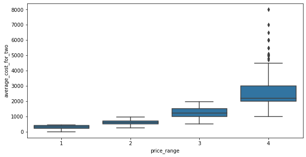

```python
plt.figure(figsize= (10,5))
sb.boxplot(data = restaurants_df, x = "price_range", y = "average_cost_for_two", color = base_color)
```

> this is a confirmation of the meaning of the price ranges, 1 means low prices & 4 means the highest category or prices

```python
# restaurants_df = restaurants_df.loc[restaurants_df.votes >= 10,:]
```

```python
restaurants_df = restaurants_df.loc[restaurants_df.rating != "Not rated"]
cuisines_df = cuisines_df.loc[cuisines_df.rating != "Not rated"]
```

```python
new_ratings = ["Poor", "Average", "Good","Very Good","Excellent"]
ratings = pd.api.types.CategoricalDtype(ordered = True,
                                                categories = new_ratings)
restaurants_df["rating"] = restaurants_df["rating"].astype(ratings)
# cuisines_df = cuisines_df.loc[cuisines_df.votes >= 10,:]
cuisines_df["rating"] = cuisines_df["rating"].astype(ratings)
```

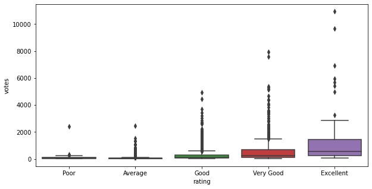

```python
plt.figure(figsize= (10,5))
sb.boxplot(data = restaurants_df, x = "rating", y = "votes")
```

> Poor and Average restaurants tend to have low count of votes, thats why I'll keep low votes in this analysis in order not to lose any major data

> Also there is one restaurant that really stands out as Poor with high count of votes, apparently people really don't like it

```python
restaurants_df.loc[(restaurants_df.rating == "Poor"),:].sort_values("votes",ascending = False).head()[:2]
```

|  | restaurant_id | restaurant_name | city | locality | cuisines | average_cost_for_two | currency | has_table_booking | has_online_delivery | is_delivering_now | price_range | rating | votes |
| --- | --- | --- | --- | --- | --- | --- | --- | --- | --- | --- | --- | --- | --- |
| 1247 | 306134 | The Wine Company | Gurgaon | Cyber Hub, DLF Cyber City | Italian, European | 2000 | Indian Rupees(Rs.) | Yes | No | No | 4 | Poor | 2412 |
| 1138 | 1683 | Pind Balluchi | Ghaziabad | Shipra Mall, Indirapuram | North Indian, Mughlai | 1000 | Indian Rupees(Rs.) | Yes | Yes | No | 3 | Poor | 322 |

The Wine Company really stands out in the Poor rating category with around 2400 votes

```python
# first drop all cities and only keep 'New Delhi', 'Gurgaon', 'Noida', 'Faridabad'
top_cities = restaurants_df.city.value_counts()[:4].index
restaurants_df = restaurants_df.loc[restaurants_df.city.isin(top_cities), :]
cuisines_df = cuisines_df.loc[cuisines_df.city.isin(top_cities),:]
```

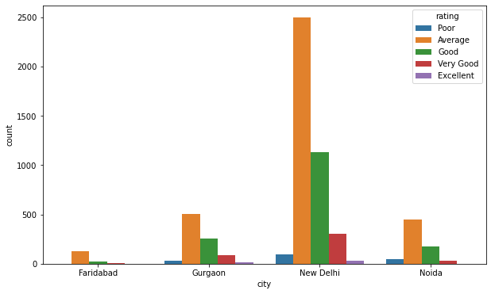

```python
plt.figure(figsize = (10,6))
sb.countplot(data =restaurants_df, x = "city", hue = "rating")
```

> Due to the large number of restaurants in New delhi, this comparison is not fair. it's better to work with proportions

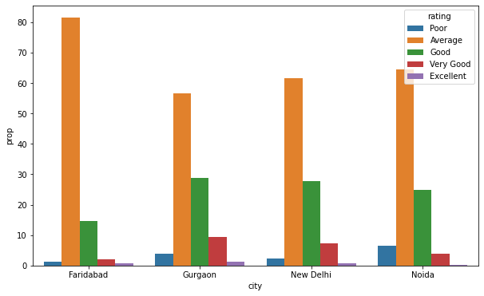

```python
plt.figure(figsize = (10,6))
city_ratings = get_proportions(restaurants_df, "city", "rating")
sb.barplot(data = city_ratings, x = "city", y = "prop", hue = "rating")
```

> all cities have a big proportion of restaurants that are rated as average.

> Faridabad have around 80% of it's restaurants rated as average.

> Gurgaon have similar or a slightly higher percentage of Good/Excellent restaurants than New Delhi, keeping in mind that New Delhi have way more number of restaurants

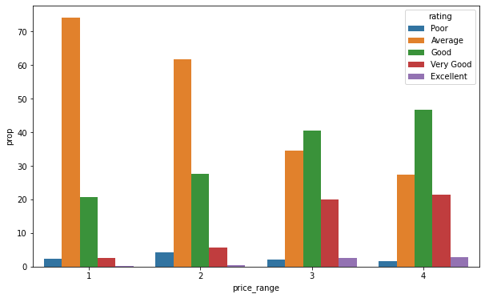

```python
price_range_ratings = get_proportions(restaurants_df, "price_range", "rating")
plt.figure(figsize = (10,6))
sb.barplot(data = price_range_ratings, x = "price_range", y = "prop", hue = "rating")
```

> Restaurants with low price ranges have more Average ratings proportions

> As we go up in price ranges restaurants tend have more Good, V.Good & Excellent proportions

> Based on this relation we can say that maybe there is a positive correlation between price ranges and restaurant ratings

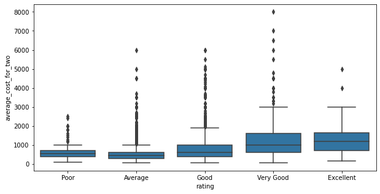

```python
plt.figure(figsize = (10,5))
sb.boxplot(data = restaurants_df, x = 'rating', y = 'average_cost_for_two', color = base_color)
# plt.ylim(ax1.get_ylim()) #
```

> Also the above box plot confirms the same conclusion from the price_range vs ratings, restaurants with higher cost to have higher ratings, this suggests the fact the more restaurants charge for their service the more the quality will be better and that's why people give higher ratings

> These outliers are useful as we can extract Poor & Average restaurants that cost alot, and don't recommend them and extract the outliers that standout in Excellent/Very Good categories and recommend them as they are value for money

```python
restaurants_df.loc[restaurants_df.rating == "Poor"].sort_values("average_cost_for_two",ascending = False).head()
```

|  | restaurant_id | restaurant_name | city | locality | cuisines | average_cost_for_two | currency | has_table_booking | has_online_delivery | is_delivering_now | price_range | rating | votes |
| --- | --- | --- | --- | --- | --- | --- | --- | --- | --- | --- | --- | --- | --- |
| 9050 | 3212 | Chicane | Noida | Spice World Mall, Sector 25 | European, North Indian, Chinese | 2500 | Indian Rupees(Rs.) | Yes | No | No | 4 | Poor | 116 |
| 9105 | 3237 | Club Ice Cube | Noida | The Great India Place, Sector 38 | North Indian, Continental, Chinese | 2400 | Indian Rupees(Rs.) | Yes | No | No | 4 | Poor | 230 |
| 8467 | 4717 | RPM - Zanzi Bar | Noida | Sector 18 | Chinese, North Indian | 2000 | Indian Rupees(Rs.) | Yes | No | No | 4 | Poor | 103 |
| 1247 | 306134 | The Wine Company | Gurgaon | Cyber Hub, DLF Cyber City | Italian, European | 2000 | Indian Rupees(Rs.) | Yes | No | No | 4 | Poor | 2412 |
| 8045 | 718 | Americana Kitchen and Bar | Noida | Centre Stage Mall, Sector 18 | American, Tex-Mex, Italian, Mexican, North Indian | 2000 | Indian Rupees(Rs.) | Yes | No | No | 4 | Poor | 221 |

```python
def extract_restaurant_name_outlier(category):
    """ Extracts outliers for a given rating category
    params:
    category: Rating category
    returns:
        restaurant_name: Restaurant name
    """
    outliers = restaurants_df.loc[restaurants_df.rating == category]
    outliers = outliers.sort_values("average_cost_for_two",ascending = False)
    restaurant_name = outliers.restaurant_name.values[0]
    return restaurant_name
```

```python
most_poor = extract_restaurant_name_outlier("Poor")
most_average = extract_restaurant_name_outlier("Average")
print(" \"{}\" & \"{}\" restaurants have the low value for money ".format(most_poor, most_average))
```

```
 "Chicane" & "Nostalgia at 1911 Brasserie - The Imperial" restaurants have the low value for money
```

```python
vry_good = extract_restaurant_name_outlier("Very Good")
excellent = extract_restaurant_name_outlier("Excellent")
print("\"{}\" & \"{}\"  restaurant have high value for money ".format(vry_good, excellent))
```

```
"Orient Express - Taj Palace Hotel" & "Masala Library"  restaurant have high value for money
```

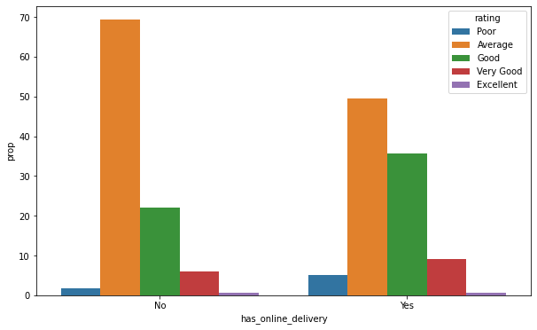

```python
plt.figure(figsize = (10,6))
has_online_delivery_ratings = get_proportions(restaurants_df,"has_online_delivery","rating")
sb.barplot(data =has_online_delivery_ratings, x = "has_online_delivery", y = "prop", hue = "rating")
```

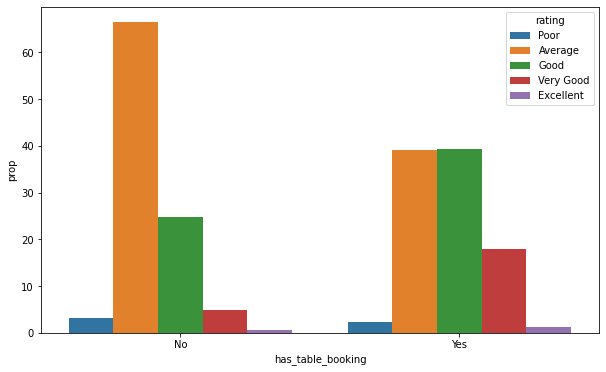

```python
plt.figure(figsize = (10,6))
has_table_booking_ratings = get_proportions(restaurants_df,"has_table_booking", "rating")
sb.barplot(data =has_table_booking_ratings, x = "has_table_booking", y = "prop", hue = "rating")
```

> Restaurants with online delivery or table bookings tend to have higher ratings

```python
# top cuisines in top cities
cuisines_df.groupby("city").cuisine.count()
```

```
city
Faridabad     326
Gurgaon      2016
New Delhi    8661
Noida        1533
Name: cuisine, dtype: int64
```

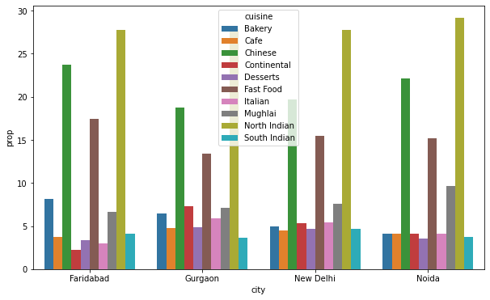

```python
plt.figure(figsize = (10,6))
city_cuisines = get_cuisines_proportions("city")
sb.barplot(data =city_cuisines, x = "city", y = "prop", hue = "cuisine")
```

> Nothing important here

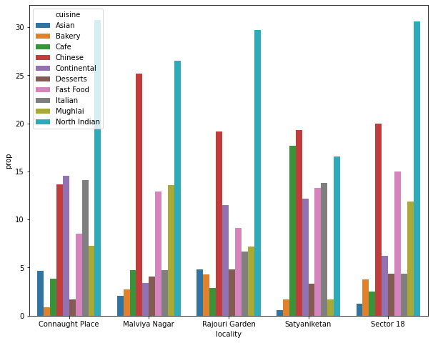

```python
plt.figure(figsize = (10,8))
locality_cuisines = get_cuisines_proportions("locality")
sb.barplot(data =locality_cuisines, x = "locality", y = "prop", hue = "cuisine")
```

> North indian cuisine is very popular in the top locals, also chinese cuisine

> Satyaniketan has a high proportion of cafes compared to other places, also Satyaniketan & Connaught Place has alot of italian & continental restaurants

> Also this graph is too crowded it needs another view

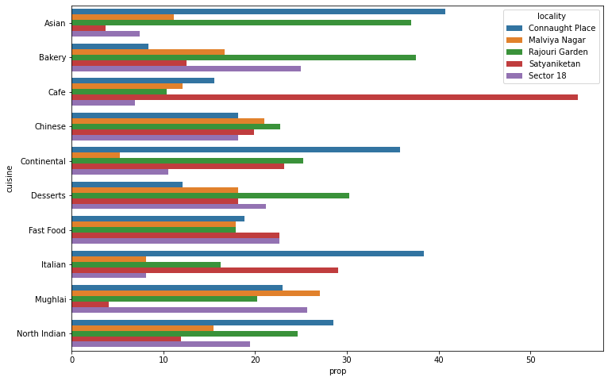

```python
plt.figure(figsize = (12,8))
locality_cuisines = get_cuisines_proportions_invert("locality")
sb.barplot(data =locality_cuisines, x = "prop", y = "cuisine", hue = "locality")
```

> It's more apparent here that Cafes are found in Satyaniketan more

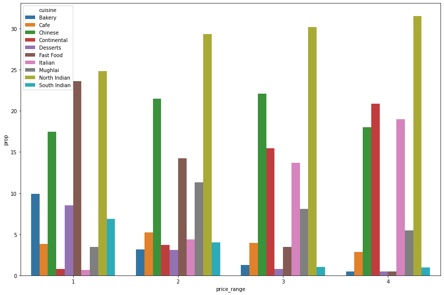

```python
plt.figure(figsize = (15,10))
price_cuisines = get_cuisines_proportions("price_range")
sb.barplot(data =price_cuisines, x = "price_range", y = "prop", hue = "cuisine")
```

> North indian & chinese cuisines has a wide price range

> As you go higher in budget you will find less of these cuisines Bakery, Desserts, Fast food, South indian cuisines.

> Italian and continental cuisines have higher price ranges

> Street food have lower price ranges

```python
cuisines_df.cuisine.value_counts()[:10].index
```

```
Index(['North Indian', 'Chinese', 'Fast Food', 'Mughlai', 'Continental',
       'Italian', 'Bakery', 'Desserts', 'Cafe', 'South Indian'],
      dtype='object')
```

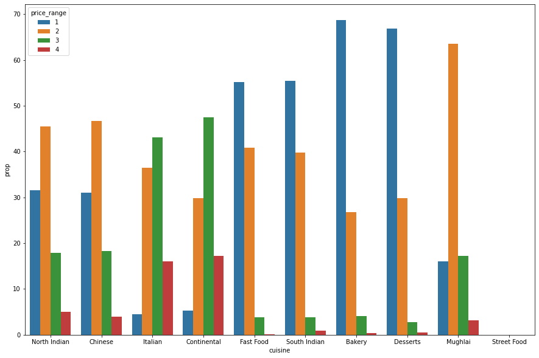

```python
cuisines_order = ['North Indian', 'Chinese', 'Italian', 'Continental', 'Fast Food','South Indian', 'Bakery'
       , 'Desserts', 'Mughlai', 'Street Food']
plt.figure(figsize = (15,10))
price_cuisines = get_cuisines_proportions_invert("price_range")
sb.barplot(data =price_cuisines, x = "cuisine", y = "prop", hue = "price_range", order = cuisines_order)
```

> North Indian and chinese cuisines have pretty similar price ranges

> Italian and Continental cuisines are also similar in price ranges, they tend to be of higher quality/price

> Fast Food and South Indian have similar price ranges they tend to be at medium - low category

> Bakery and Desserts have similar price ranges they tend to be at medium - low category but more on the low end

> Mughlai tend to be in the medium price range territory

> Apparently South indian cuisine tend to be more cheaper than North indian cuisine

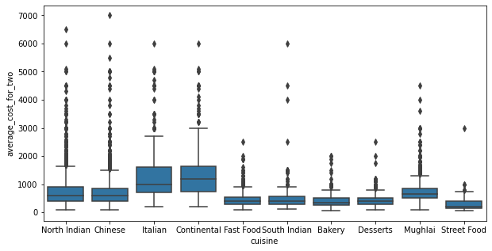

```python
plt.figure(figsize = (10,5))
# tmp_cuisine = cuisines_df.loc[cuisines_df.cuisine.isin(cuisines_order),:]
sb.boxplot(data = cuisines_df, x = 'cuisine', y = 'average_cost_for_two', color = base_color, order = cuisines_order)
# plt.ylim(ax1.get_ylim()) #
```

> The distribution of `average_price_for_two` captures the relation between cuisine and price ranges better, we can see here that Italian and Continental cuisines have higher price ranges, then in the next level we can see North Indian and chinese having also pretty similar price ranges, also Mughlai cuisine is close to them having a narrower distribution, then in the next category we'll find Fast food, South Indian, Desserts & Bakery having similar price ranges, with bakery having the lower median, and the lowest price range of all is of course Street Food

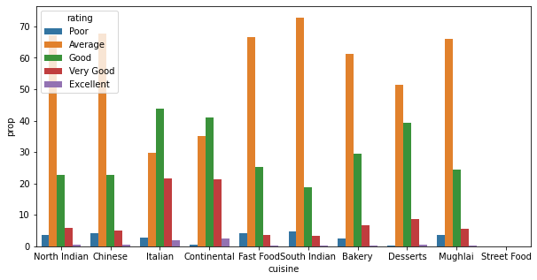

```python
# cuisines_order = ['North Indian', 'Chinese', 'Italian',  'Continental', 'Fast Food', 'Mughlai', 'Bakery',
#        'South Indian', 'Desserts', 'Street Food']
plt.figure(figsize = (10,5))
rating_cuisines = get_cuisines_proportions_invert("rating")
sb.barplot(data =rating_cuisines, x = "cuisine", y = "prop", hue = "rating", order = cuisines_order)
```

> Italian and continental restaurants also tend to be rated higher than other restaurants, probably justifying the higher price ranges as restaurants who will charge more probably will have a higher quality overall for their services

### Talk about some of the relationships you observed in this part of the investigation. How did the feature(s) of interest vary with other features in the dataset?

> Poor and Average ratings have the lowest number of votes, as you go higher in rating the number of votes increase, there was something interesting here as there was one restaurant the standed out as really poor as it has very high number of ratings related to others which was The Wine Company

> For the cities, Gurgaon have similar or a slightly higher percentage of Good/Excellent restaurants than New Delhi, keeping in mind that New Delhi have way more number of restaurants, Also 80% of Faridabad restaurants are rated as Average

> There is a positive correlation between price ranges/ average cost for two with ratings, in other words as we go higher in price restaurants probably will be rated better, this suggests the fact the more restaurants charge for their service the more the quality will be better and that's why people give higher ratings

> Also the outliers in the average_cost_for_two were really useful as we can recommend the value for money for these restaurants in other words some restaurants tend to charge really high prices but they are rated as Poor and some charge these high prices and they are Excellent Some examples are: "Chicane" & "Nostalgia at 1911 Brasserie - The Imperial" restaurants have low value for money "Orient Express - Taj Palace Hotel" & "Masala Library" restaurant have high value for money

> Restaurants with online delivery or table bookings tend to be rated higher, but this is not necessarily true as correlation doesn't imply causation

> As for cuisines when looking at top locations vs cuisines what standed out is that Satyaniketan apparently is more of a Cafe area

> when looking at price ranges vs cuisines we find out some interesting stuff
> - North Indian and chinese cuisines have pretty similar price ranges
> - Italian and Continental cuisines are also similar in price ranges, they tend to be of higher quality/price
> - Fast Food and South Indian have similar price ranges they tend to be at medium - low category
> - Bakery and Desserts have similar price ranges they tend to be at medium - low category but more on the low end
> - Mughlai tend to be in the medium price range territory, also closer to North Indian, Chinese cuisines price ranges
> - Apparently South indian cuisine tend to be more cheaper than North indian cuisine

> Italian and continental restaurants also tend to be rated higher than other restaurants, justifying the previous assumption that restaurants who will charge more probably will have a higher quality overall for their services

### Did you observe any interesting relationships between the other features (not the main feature(s) of interest)?

> Only one relation was explored between other features, which is the relation between price ranges & average cost for two, the assumption at first was 1 means low price range and 4 means high, this was confirmed using a box plot and seeing the correlation between the two variables

## Multivariate Exploration

```python
restaurants_df.info()
```

```
<class 'pandas.core.frame.DataFrame'>
Int64Index: 5785 entries, 865 to 9108
Data columns (total 13 columns):
 #   Column                Non-Null Count  Dtype
---  ------                --------------  -----
 0   restaurant_id         5785 non-null   object
 1   restaurant_name       5785 non-null   object
 2   city                  5785 non-null   object
 3   locality              5785 non-null   object
 4   cuisines              5785 non-null   object
 5   average_cost_for_two  5785 non-null   int64
 6   currency              5785 non-null   object
 7   has_table_booking     5785 non-null   object
 8   has_online_delivery   5785 non-null   object
 9   is_delivering_now     5785 non-null   object
 10  price_range           5785 non-null   category
 11  rating                5785 non-null   category
 12  votes                 5785 non-null   int64
dtypes: category(2), int64(2), object(9)
memory usage: 714.0+ KB
```

```python
restaurants_df.columns
```

```
Index(['restaurant_id', 'restaurant_name', 'city', 'locality', 'cuisines',
       'average_cost_for_two', 'currency', 'has_table_booking',
       'has_online_delivery', 'is_delivering_now', 'price_range', 'rating',
       'votes'],
      dtype='object')
```

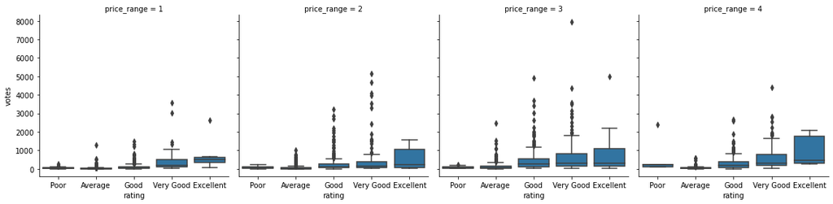

```python
g = sb.FacetGrid(data = restaurants_df, col = 'price_range', size = 4)
g.map(sb.boxplot, 'rating', 'votes')
```

> Poor and Average ratings have low amount of votes in general

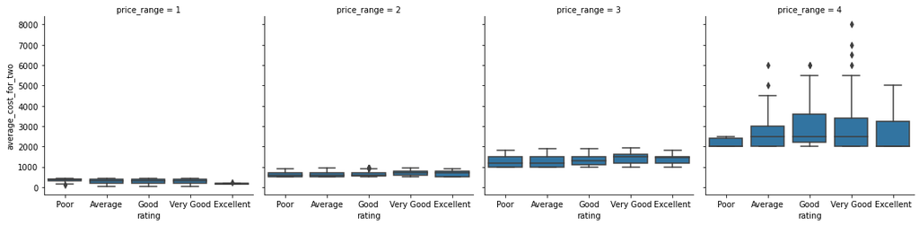

```python
plt.figure(figsize=(10,10))
g = sb.FacetGrid(data = restaurants_df, col = 'price_range', size = 4)
g.map(sb.boxplot, 'rating', 'average_cost_for_two')
```

```python
top_10_cuisine_df = cuisines_df.loc[cuisines_df.cuisine.isin(cuisines_order)]
```

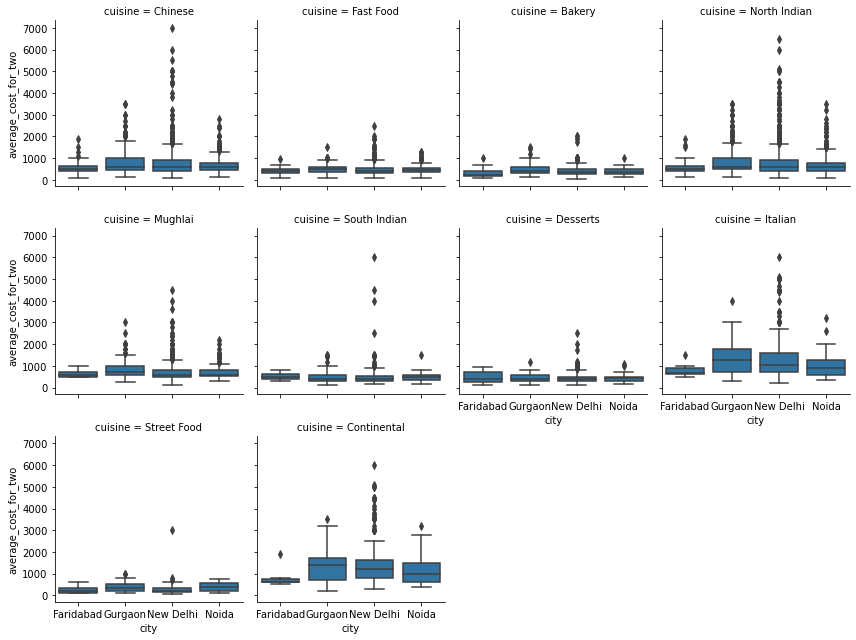

```python
# plt.figure(figsize=(10,10))
g = sb.FacetGrid(data = top_10_cuisine_df,col_wrap = 4,col = 'cuisine')
g.map(sb.boxplot, 'city', 'average_cost_for_two')
```

cost distribution in Faridabad tend to be low for all cuisines compared to other cities

Apparently due to the fact that it has a large number of restaurants, New delhi have the most wide range of restaurant prices in probably every cuisine with some overpriced restaurants in these cuisines : chinese, north/south indian, italian and continental, Gurgaon comes close to New Delhi but it doesn't have these much of highly priced restaurants

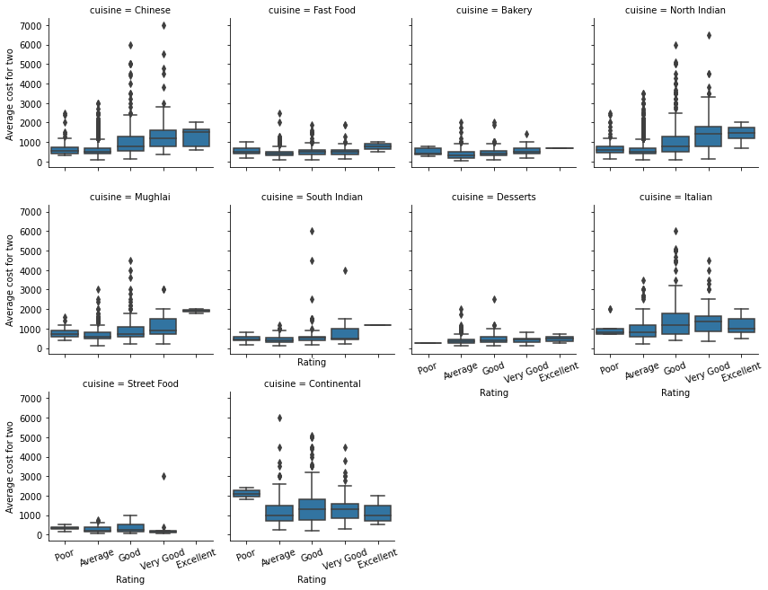

```python
# top_10_cuisine_df = cuisines_df.loc[cuisines_df.cuisine.isin(cuisines_order)]

g = sb.FacetGrid(data = top_10_cuisine_df,col_wrap = 4,col = 'cuisine')
g.map(sb.boxplot, 'rating', 'average_cost_for_two')
# plt.title("Rating vs Average cost for two per Cuisine")
g.set_xticklabels(rotation = 20)#.xticks(rotation = 15)
for ax in g.axes[5:]:
    ax.set_xlabel("Rating")
for i in [0,4,8]:
    g.axes[i].set_ylabel("Average cost for two")
```

> Generally restaurants which charge higher for their services, will get better ratings, this is apparent in most cuisines with some anomalies

> This pattern fails in Italian cuisine as we find some Excellent restaurants falling in lower price ranges

> Continental restaurants rated as Poor have very high costs, they have low value for money.

> There is no street food restaurant rated as Excellent.

### Talk about some of the relationships you observed in this part of the investigation. Were there features that strengthened each other in terms of looking at your feature(s) of interest?

> I added the number of votes to my price range vs ratings investigation, after plotting the three variables together it strengthened the previous conclusion of having better ratings for higher prices

> Also the average cost per city per cuisine showed that Faridabad have generally low cost restaurants on the other hand New Delhi had a much more wide distribution of prices for each cuisine

> After plotting Ratings vs average cost for each cuisine, We find again the same positive correlation between ratings and restaurants costs for every cuisine with few anomalies in some cuisines

### Were there any interesting or surprising interactions between features?

> Nothing Extra interesting or new was found to be added in here